# Assignment 9

David Du

3/13/2018

## Chapter 13

# Problem:

What does it mean for a flight to have a missing tailnum? What do the tail numbers that don’t have a matching record in planes have in common? (Hint: one variable explains ~90% of the problems.)

# Solution:

```r
anti_join(flights, planes, by = "tailnum") %>%
count(carrier, sort=TRUE)
```

```
## # A tibble: 10 x 2
##    carrier     n
##    <chr>   <int>
##  1 MQ      25397
##  2 AA      22558
##  3 UA       1693
##  4 9E       1044
##  5 B6        830
##  6 US        699
##  7 FL        187
##  8 DL        110
##  9 F9         50
## 10 WN         38
```

Here, I have anti_join function which could find out the unmatched record, here we need to find out flights have missing tailnum. Therefore, I use this function to find out Amercian Airline and Envoy Airline have most missing record for tailnum. Missing tailnum could mean that the flight is unregistered, unlicensed flight.

## Chapter 14

# Problem and Solution

Create regular expressions to find all words that:

Start with a vowel.

That only contain consonants. (Hint: thinking about matching “not”-vowels.)

End with ed, but not with eed.

[interactive chart not shown]

End with ing or ise.

## Chapter 15

# Problem

There are some suspiciously high numbers in tvhours. Is the mean a good summary?

```
##    Min. 1st Qu.  Median    Mean 3rd Qu.    Max.    NA's
##   0.000   1.000   2.000   2.981   4.000  24.000   10146
```

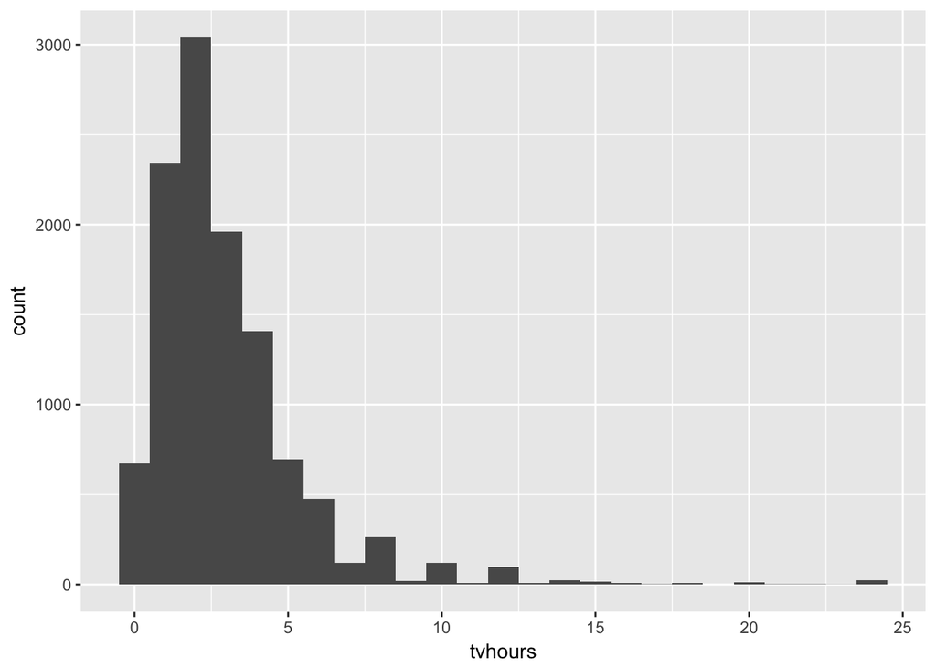

## Chapter 16

Functions need to be used prior to do exercises

# Problem

What makes the distribution of diamonds$carat and flights$sched_dep_time similar?

# Solution

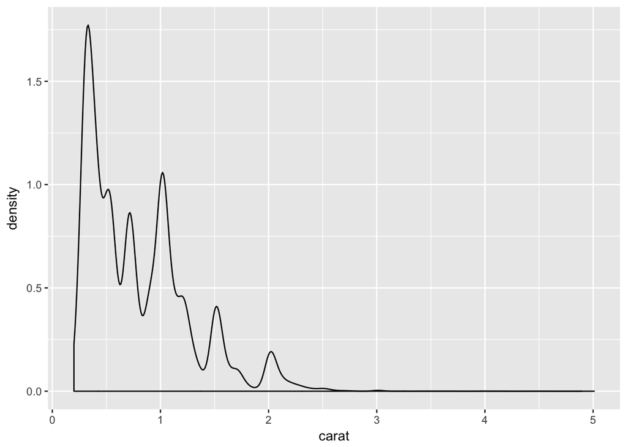

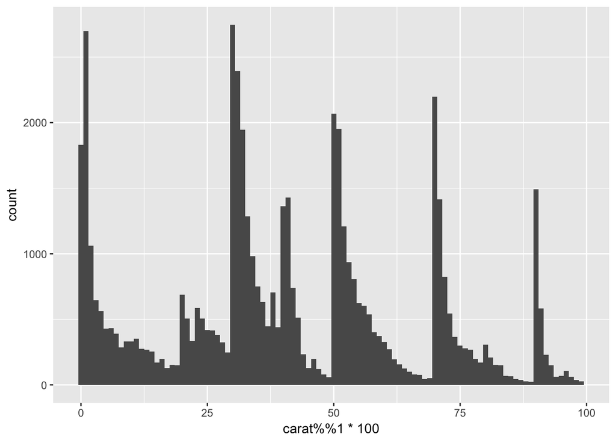

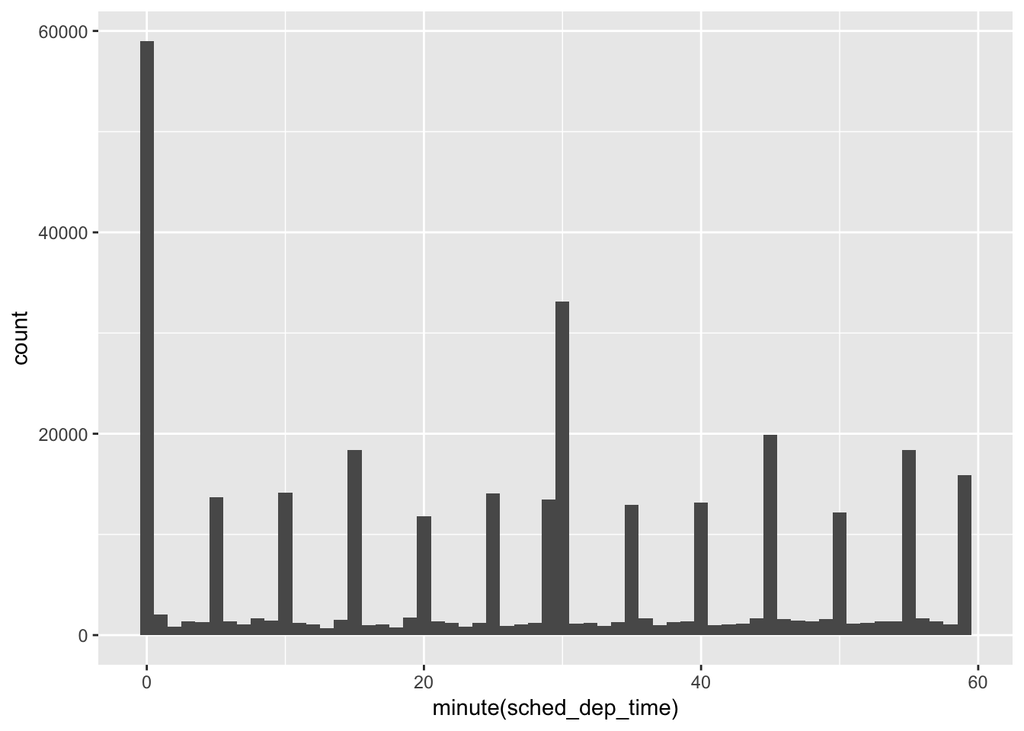

## Summary of Contribution

David: For chapter 13, I have learnt anti_join function in order to find out the number of flight that has missing record of tailnum. For chapter 14, I have learnt the ways to filter with strings with specific requirements. For chapter 15, I have draw historgam in order to visualize the TV hours. In chapter 16, I have manuipulated with time and dates to answer the question. In this lab, I have implemented with ggplot, geom_density, and geom_histogram function.